# Materiais Compósitos

Prof. Dr. Jean Rodrigues

2022-05-22

## Exercício

Considere um compósito plano de fibra de vidro e matriz de resina epóxi, com fração volumétrica de 45% de fibra, carregado como mostrado abaixo. A configuração do laminado é dada como sendo [+45°/0°/90°]$^t$ e admite-se a espessura de cada camada como sendo de 0,2 mm. Considerando as propriedades dadas abaixo, determinar:

1. as equações constitutivas do laminado;
2. as deformações centrais e curvaturas da placa;
3. as deformações em cada camada nas direções globais (X-Y) e direções principais (1-2);
4. as tensões em cada camada nas direções globais (X-Y) e direções principais (1-2);
5. a possível ocorrência de falha usando o critério de tensão máxima e o critério de Azzi-Tsai-Hill.

Dados:

E1 = 39 GPa

E2 = 8,3 GPa

$\upsilon$ 12 = 0,26

Resistência à tração na direção 1 (Xt) = 1062 MPa

Resistência à compressão na direção 1 (Xc) = 958 MPa

Resistência compressão na direção 2 (Yc) = 118 MPa

Resistência ao cisalhamento no plano (S12) = 78 MPa

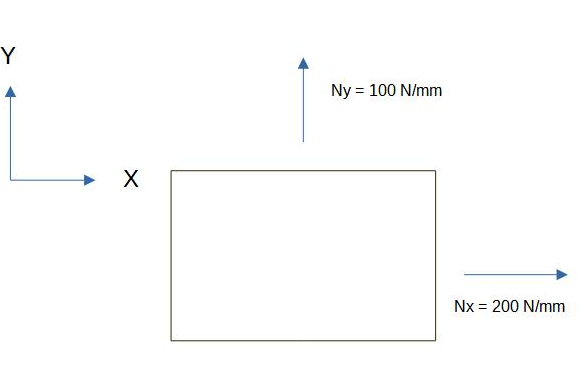

[figure not shown]

Declarando os dados de entrada do laminado:

*E1* é o módulo de elasticidade da fibra na direção 1, unidade em GPa.

*E2* é o módulo de elasticidade da fibra na direção 2, unidade em GPa.

*G12* é o módulo de cisalhamento, unidade em GPa.

*v12* é o Coeficiente de Poisson maior, unidade admimensional.

*Xt* é a resistência à tração longitudinal da lâmina unidade em GPa.

*Xc* é a resistência à compressão longitudinal da lâmina, unidade em GPa.

*Yt* é a resistência à tração transversal da lâmina, unidade em GPa.

*Yc* é a resistência à compressão transversal da lâmina, unidade em GPa.

*S12* é a resistência ao cisalhamento no plano da lâmina, unidade em GPa.

```r
E1=39
E2=8.3
G12=4.
v12=0.26
Xt=1.062
Xc=0.958
Yt=0.031
Yc=0.118
S12=0.078
```

Os valores em Mega Pascal (MPa) foram convertidos para a unidade padrão Giga Pascal (GPa).

Declarando os ângulos (teta) de alinhamento da fibra na direção global (X-Y):

```r
teta_k1=45 #angulo teta
teta_k2=0
teta_k3=90
```

Declarando as curvaturas em razão da cota Z:

```r
z_k0=-0.0003
z_k1=-0.0001
z_k2=0.0001
z_k3=0.0003
```

Os valores em milímetros (mm) foram convertidos para a unidade padrão metro(m).

Declarando os valores de carregamento (esforços normais):

```r
Nx=200000
Ny=100000
```

A unidade padrão é Newton por Metro (N/m), sendo:

$Nx$ a Força normal na direção X;

$Ny$ a Força normal na direção Y.

Cálculo do Coeficiente de Poisson menor (v21):

```r
v21 = v12*(E2/E1)
```

O comando *print* retorna o valor do objeto v21.

```r
print(v21)
```

```
## [1] 0.05533333
```

Cáculo dos Elementos da Matriz de Rigidez [Q] para lâminas ortotrópicas no estado plano de tensão(GPa).

Como a matriz [Q] é simétrica, calcula-se apenas os elementos acima da diagonal princial.

```r
  Q11 = E1/(1-v12*v21)
  Q12 = v21*E1/(1-v12*v21)
  Q16 = 0
  Q22 = E2/(1-v12*v21)
  Q26 = 0
  Q66 = G12
```

Matriz de Rigidez [Q] de Lâmina Ortotrópica no Estado Plano de Tensão em GPa.

```r
 Q_orto = matrix(c( Q11, Q12, Q16,
                    Q12, Q22, Q26,
                    Q16, Q26, Q66),
          nrow = 3, ncol = 3, byrow = TRUE)
```

Elementos da matriz [Q] Ortotrópica:

```r
print(Q_orto)
```

```
##          [,1]     [,2] [,3]
## [1,] 39.56927 2.189500    0
## [2,]  2.18950 8.421152    0
## [3,]  0.00000 0.000000    4
```

### Calculo dos elementos da matriz de rotação para camada k1 (45º).

```r
  teta_rad = teta_k1*pi/180
  T_11 = (cos(teta_rad))^2
  T_12 = (sin(teta_rad))^2
  T_13 = 2*cos(teta_rad)*sin(teta_rad)
  T_21 = (sin(teta_rad))^2
  T_22 = (cos(teta_rad))^2
  T_23 = -2*cos(teta_rad)*sin(teta_rad)
  T_31 = -cos(teta_rad)*sin(teta_rad)
  T_32 = cos(teta_rad)*sin(teta_rad)
  T_33 = (cos(teta_rad))^2 - (sin(teta_rad))^2
```

Matriz de Rotação [T_k1] (45º):

```r
T_k1 = matrix(c(  T_11, T_12, T_13,
                  T_21, T_22, T_23,
                  T_31, T_32, T_33),
         nrow = 3, ncol = 3, byrow = TRUE)
```

Elementos da matriz [T_k1]:

```r
print(T_k1)
```

```
##      [,1] [,2]          [,3]
## [1,]  0.5  0.5  1.000000e+00
## [2,]  0.5  0.5 -1.000000e+00
## [3,] -0.5  0.5  2.220446e-16
```

Matriz inversa da matriz de rotação [T_k1] para camada k1:

```r
  T_k1_inv = solve(T_k1)
```

Elementos da matriz [T_k1_inv]:

```r
print(T_k1_inv)
```

```
##      [,1] [,2]          [,3]
## [1,]  0.5  0.5 -1.000000e+00
## [2,]  0.5  0.5  1.000000e+00
## [3,]  0.5 -0.5  2.220446e-16
```

Matriz transposta da matriz de rotação [T_k1] para camada k1:

```r
  T_k1_transp = t(T_k1)
```

Elementos da matriz [T_k1_transp]:

```r
print(T_k1_transp)
```

```
##      [,1] [,2]          [,3]
## [1,]  0.5  0.5 -5.000000e-01
## [2,]  0.5  0.5  5.000000e-01
## [3,]  1.0 -1.0  2.220446e-16
```

Matriz transposta da inversa da da matriz de rotação da camada k1 [T_k1_transp_inv].

```r
  T_k1_transp_inv = t(T_k1_inv)
```

Elementos da matriz transposta da inversa da camada k1 [T_k1_transp_inv]:

```r
print(T_k1_transp_inv)
```

```
##      [,1] [,2]          [,3]
## [1,]  0.5  0.5  5.000000e-01
## [2,]  0.5  0.5 -5.000000e-01
## [3,] -1.0  1.0  2.220446e-16
```

Cálculo da matriz de rigidez [Q_Barra_k1] de lâminas ortotropicas angulares para camada k1:

```r
 Q_Barra_k1 = T_k1_inv%*%Q_orto%*%T_k1_transp_inv
```

Elementos da matriz [Q_Barra_1]:

```r
print(Q_Barra_k1)
```

```
##           [,1]      [,2]      [,3]
## [1,] 17.092355  9.092355  7.787029
## [2,]  9.092355 17.092355  7.787029
## [3,]  7.787029  7.787029 10.902856
```

### Calculo dos elementos da matriz de rotação para camada k2 (0º).

```r
  teta_rad = teta_k2*pi/180
  T_11 = (cos(teta_rad))^2
  T_12 = (sin(teta_rad))^2
  T_13 = 2*cos(teta_rad)*sin(teta_rad)
  T_21 = (sin(teta_rad))^2
  T_22 = (cos(teta_rad))^2
  T_23 = -2*cos(teta_rad)*sin(teta_rad)
  T_31 = -cos(teta_rad)*sin(teta_rad)
  T_32 = cos(teta_rad)*sin(teta_rad)
  T_33 = (cos(teta_rad))^2 - (sin(teta_rad))^2
```

Matriz de Rotação [T_k2] (0º):

```r
T_k2 = matrix(c(  T_11, T_12, T_13,
                  T_21, T_22, T_23,
                  T_31, T_32, T_33),
         nrow = 3, ncol = 3, byrow = TRUE)
```

Elementos da matriz [T_k2]:

```r
print(T_k2)
```

```
##      [,1] [,2] [,3]
## [1,]    1    0    0
## [2,]    0    1    0
## [3,]    0    0    1
```

Matriz inversa da matriz de rotação [T_k2] para camada k2:

```r
  T_k2_inv = solve(T_k2)
```

Elementos da matriz [T_k2_inv]:

```r
print(T_k2_inv)
```

```
##      [,1] [,2] [,3]
## [1,]    1    0    0
## [2,]    0    1    0
## [3,]    0    0    1
```

Matriz transposta da matriz de rotação [T_k2] para camada k2:

```r
  T_k2_transp = t(T_k2)
```

Elementos da matriz [T_k2_transp]:

```r
print(T_k2_transp)
```

```
##      [,1] [,2] [,3]
## [1,]    1    0    0
## [2,]    0    1    0
## [3,]    0    0    1
```

Matriz transposta da inversa da da matriz de rotação da camada k2 [T_k2_transp_inv].

```r
  T_k2_transp_inv = t(T_k2_inv)
```

Elementos da matriz transposta da inversa da camada k2 [T_k2_transp_inv]:

```r
print(T_k2_transp_inv)
```

```
##      [,1] [,2] [,3]
## [1,]    1    0    0
## [2,]    0    1    0
## [3,]    0    0    1
```

Cálculo da matriz de rigidez [Q_Barra_k2] de lâminas ortotropicas angulares para camada k2:

```r
 Q_Barra_k2 = T_k2_inv%*%Q_orto%*%T_k2_transp_inv
```

Elementos da matriz [Q_Barra_k2]:

```r
print(Q_Barra_k2)
```

```
##          [,1]     [,2] [,3]
## [1,] 39.56927 2.189500    0
## [2,]  2.18950 8.421152    0
## [3,]  0.00000 0.000000    4
```

### Calculo dos elementos da matriz de rotação para camada k3 (90º).

```r
  teta_rad = teta_k3*pi/180
  T_11 = (cos(teta_rad))^2
  T_12 = (sin(teta_rad))^2
  T_13 = 2*cos(teta_rad)*sin(teta_rad)
  T_21 = (sin(teta_rad))^2
  T_22 = (cos(teta_rad))^2
  T_23 = -2*cos(teta_rad)*sin(teta_rad)
  T_31 = -cos(teta_rad)*sin(teta_rad)
  T_32 = cos(teta_rad)*sin(teta_rad)
  T_33 = (cos(teta_rad))^2 - (sin(teta_rad))^2
```

Matriz de Rotação [T_k3] (90º):

```r
T_k3 = matrix(c(  T_11, T_12, T_13,
                  T_21, T_22, T_23,
                  T_31, T_32, T_33),
         nrow = 3, ncol = 3, byrow = TRUE)
```

Elementos da matriz [T_k3]:

```r
print(T_k3)
```

```
##               [,1]         [,2]          [,3]
## [1,]  3.749152e-33 1.000000e+00  1.224606e-16
## [2,]  1.000000e+00 3.749152e-33 -1.224606e-16
## [3,] -6.123032e-17 6.123032e-17 -1.000000e+00
```

Matriz inversa da matriz de rotação [T_k3] para camada k3:

```r
  T_k3_inv = solve(T_k3)
```

Elementos da matriz [T_k3_inv]:

```r
print(T_k3_inv)
```

```
##              [,1]          [,2]          [,3]
## [1,] 3.749152e-33  1.000000e+00 -1.224606e-16
## [2,] 1.000000e+00  3.749152e-33  1.224606e-16
## [3,] 6.123032e-17 -6.123032e-17 -1.000000e+00
```

Matriz transposta da matriz de rotação [T_k3] para camada k3:

```r
  T_k3_transp = t(T_k3)
```

Elementos da matriz [T_k3_transp]:

```r
print(T_k3_transp)
```

```
##              [,1]          [,2]          [,3]
## [1,] 3.749152e-33  1.000000e+00 -6.123032e-17
## [2,] 1.000000e+00  3.749152e-33  6.123032e-17
## [3,] 1.224606e-16 -1.224606e-16 -1.000000e+00
```

Matriz transposta da inversa da da matriz de rotação da camada k3 [T_k3_transp_inv].

```r
  T_k3_transp_inv = t(T_k3_inv)
```

Elementos da matriz transposta da inversa da camada k3 [T_k3_transp_inv]:

```r
print(T_k3_transp_inv)
```

```
##               [,1]         [,2]          [,3]
## [1,]  3.749152e-33 1.000000e+00  6.123032e-17
## [2,]  1.000000e+00 3.749152e-33 -6.123032e-17
## [3,] -1.224606e-16 1.224606e-16 -1.000000e+00
```

Cálculo da matriz de rigidez [Q_Barra_k3] de lâminas ortotropicas angulares para camada k3:

```r
 Q_Barra_k3 = T_k3_inv%*%Q_orto%*%T_k3_transp_inv
```

Elementos da matriz [Q_Barra_k3]:

```r
print(Q_Barra_k3)
```

```
##              [,1]         [,2]         [,3]
## [1,] 8.421152e+00 2.189500e+00 1.082765e-16
## [2,] 2.189500e+00 3.956927e+01 1.798933e-15
## [3,] 1.082765e-16 1.798933e-15 4.000000e+00
```

#### Voltando novamente as questões do início do exercício:

##### a) as equações constitutivas do laminado.

##### Cálculo da matriz de rigidez extensional no plano, matriz [A B B D].

Os esforços normais $Nx$ e $Ny$ estão em $N/mm$, uma vez que a unidade padrão é $N/m$, deve-se converter a unidade apresentada pelo exercício para a unidade padrão.

Portanto, temos:

$\left[\dfrac {N}{mm}\right]=\left[\dfrac {N}{m*10^{-3}}\right]=\left[\dfrac {N*10^{3}}{m}\right]$

Para

$[GPa*m^2]$

Temos

$GPa*m^2 = \dfrac{N}{m^2}*10^{9}*m^2=\left[ N*10^{9}\right]$

Aplicando na fórmula abaixo temos:

```r
A = (Q_Barra_k1*(z_k1-z_k0)+Q_Barra_k2*(z_k2-z_k1)+Q_Barra_k3*(z_k3-z_k2))*10^9

B = 1/2*(Q_Barra_k1*(z_k1^2-z_k0^2)+Q_Barra_k2*(z_k2^2-z_k1^2)+Q_Barra_k3*(z_k3^2-z_k2^2))*10^9

D = 1/3*(Q_Barra_k1*(z_k1^3-z_k0^3)+Q_Barra_k2*(z_k2^3-z_k1^3)+Q_Barra_k3*(z_k3^3-z_k2^3))*10^9
```

Equações Constitutivas do Laminado [ABBD].

```r
  AB = cbind(A, B) # juntando as matrizes por linha usando o comando cbind
  BD = cbind(B, D)
  ABBD = rbind(AB, BD) # juntando as matrizes por coluna usando o comando rbind
```

Teste para saber se [ABBD] é uma matriz e não houve nenhum erro ao juntarmos as mesmas:

```r
  is.matrix(ABBD)
```

```
## [1] TRUE
```

Os elementos da matriz [ABBD]:

```r
print(ABBD)
```

```
##               [,1]          [,2]         [,3]          [,4]          [,5]
## [1,] 13016555.5120  2694270.9108 1557405.8792 -346.84812164 -276.11423006
## [2,]  2694270.9108 13016555.5120 1557405.8792 -276.11423006  899.07658176
## [3,]  1557405.8792  1557405.8792 3780571.1503 -311.48117585 -311.48117585
## [4,]     -346.8481     -276.1142    -311.4812    0.24749658    0.09923574
## [5,]     -276.1142      899.0766    -311.4812    0.09923574    0.49668152
## [6,]     -311.4812     -311.4812    -276.1142    0.06748759    0.06748759
##               [,6]
## [1,] -311.48117585
## [2,] -311.48117585
## [3,] -276.11423006
## [4,]    0.06748759
## [5,]    0.06748759
## [6,]    0.13182475
```

#### b) as deformações centrais e curvaturas da placa.

Cálculo da matriz (abcd) fazendo a Inversão por etapa:

```r
# matrizes asterisco parcialmente invertida

  A_ast = solve(A) # m/N
  B_ast = -1*(A_ast)%*%(B)
  C_ast = t(-1*(B_ast))
  D_ast = (D)+(B)%*%(B_ast)

# matriz abcd invertida totalmente

  a = (A_ast)+(B_ast)%*%(solve(D_ast))%*%t(B_ast)
  b = B_ast%*%(solve(D_ast))
  c = t(b)
  d = solve(D_ast)
  ab = cbind(a, b)
  cd = cbind(c, d)
  abcd = rbind(ab, cd)
```

```r
print(abcd)
```

```
##               [,1]          [,2]          [,3]          [,4]          [,5]
## [1,]  8.622639e-08 -1.641448e-08 -1.503154e-08  4.023468e-05  0.0000481984
## [2,] -1.641448e-08  1.128957e-07 -3.709664e-08  1.062389e-04 -0.0002912646
## [3,] -1.503154e-08 -3.709664e-08  3.466969e-07  1.879955e-04  0.0001824934
## [4,]  4.023468e-05  1.062389e-04  1.879955e-04  5.211197e+00 -0.8934061016
## [5,]  4.819840e-05 -2.912646e-04  1.824934e-04 -8.934061e-01  3.0354457897
## [6,]  8.819692e-05  2.449929e-04  4.133337e-04 -1.470629e+00 -1.2887005161
##               [,6]
## [1,]  8.819692e-05
## [2,]  2.449929e-04
## [3,]  4.133337e-04
## [4,] -1.470629e+00
## [5,] -1.288701e+00
## [6,]  1.065149e+01
```

Cálculo das deformações Normais no Plano Médio (m/m), matriz [e0]:

```r
   N = matrix(c(200000,100000,0), ncol = 1, nrow = 3)
  e0 =  a %*% N
```

Elementos da matriz [e0]:

```r
print(e0)
```

```
##              [,1]
## [1,]  0.015603829
## [2,]  0.008006676
## [3,] -0.006715972
```

Cálculo das curvaturas no Plano Médio (m/m):

```r
k = c %*% N
```

Elementos da matriz das curvaturas[k]:

```r
print(k)
```

```
##           [,1]
## [1,]  18.67083
## [2,] -19.48678
## [3,]  42.13867
```

#### c) as deformações em cada camada nas direções globais (X-Y) e direções principais (1-2). Deformações em cada camada nas direções globais (X-Y) nas camadas de 45º,0º e 90º(m/m).

Deformações na direção global:

```r
  exy_k1 = e0 +z_k1*k
  exy_k2 = e0 +z_k2*k
  exy_k3 = e0 +z_k3*k
```

Deformações em cada camada nas direções principais (1-2) nas camadas de 45º,0º e 90º.

```r
  e12_k1 = T_k1_transp_inv %*% exy_k1
  e12_k2 = T_k2_transp_inv %*% exy_k2
  e12_k3 = T_k3_transp_inv %*% exy_k3
```

4. as tensões em cada camada nas direções globais (X-Y) e direções principais (1-2).

Tensão na direção global:

```r
  txy_k1 = Q_Barra_k1%*%exy_k1 # GPa
  txy_k2 = Q_Barra_k2%*%exy_k2 # GPa
  txy_k3 = Q_Barra_k3%*%exy_k3 # GPa
```

Tensão na direção principal:

```r
  t12_k1 = T_k1 %*% txy_k1
  t12_k2 = T_k2 %*% txy_k2
  t12_k3 = T_k3 %*% txy_k3
```

5. a possível ocorrência de falha usando o critério de tensão máxima e o critério de Azzi-Tsai-Hill.

##### Critério de falha em compósitos:

##### 1) Critério de tensão máxima

##### Para a lamina 45º k1

```r
if (t12_k1[1,1] < Xt) {
  cat("Lamina k1 dir. 1 = Não falha")
} else {
  cat("Lamina k1 dir. 1 = Falha")
}
```

```
## Lamina k1 dir. 1 = Não falha
```

```r
if (t12_k1[2,1] < Yt) {
  cat("Lamina k1 dir. 2 = Não falha")
} else {
  cat("Lamina k1 dir. 2 = Falha")
}
```

```
## Lamina k1 dir. 2 = Falha
```

```r
if (abs(t12_k1[3,1]) < S12) {
  cat("Lamina k1 dir. 12 = Não falha")
} else {
  cat("Lamina k1 dir. 12 = Falha")
}
```

```
## Lamina k1 dir. 12 = Não falha
```

Analisando todas as tensões simutaneamente.

```r
if (t12_k1[1,1] < Xt && t12_k1[2,1] < Yt && abs(t12_k1[3, 1] < Yc)) {
  cat("Lamina k1 = Compósito não falha")
} else {
  cat("Lamina k1 = Cómposito falha")
}
```

```
## Lamina k1 = Cómposito falha
```

##### Para a lamina 0º k2

```r
if (t12_k2[1,1] < Xt) {
  cat("Lamina k2 dir. 1 = Não falha")
} else {
  cat("Lamina k2 dir. 1 = Falha")
}
```

```
## Lamina k2 dir. 1 = Não falha
```

```r
if (t12_k2[2,1] < Yt) {
  cat("Lamina k2 dir. 2 = Não falha")
} else {
  cat("Lamina k2 dir. 2 = Falha")
}
```

```
## Lamina k2 dir. 2 = Falha
```

```r
if (abs(t12_k2[3,1]) < S12) {
  cat("Lamina k2 dir. 12 = Não falha")
} else {
  cat("Lamina k2 dir. 12 = Falha")
}
```

```
## Lamina k2 dir. 12 = Não falha
```

Analisando todas as tensões simutaneamente.

```r
if (t12_k2[1,1] < Xt && t12_k2[2,1] < Yt && abs(t12_k2[3, 1] < Yc)) {
  cat("Lamina k2 = Compósito não falha")
} else {
  cat("Lamina k2 = Cómposito falha")
}
```

```
## Lamina k2 = Cómposito falha
```

##### Para a lamina 90º k3

```r
if (t12_k3[1,1] < Xt) {
  cat("Lamina k3 dir. 1 = Não falha")
} else {
  cat("Lamina k3 dir. 1 = Falha")
}
```

```
## Lamina k3 dir. 1 = Não falha
```

```r
if (t12_k3[2,1] < Yt) {
  cat("Lamina k3 dir. 2 = Não falha")
} else {
  cat("Lamina k3 dir. 2 = Falha")
}
```

```
## Lamina k3 dir. 2 = Falha
```

```r
if (abs(t12_k3[3,1]) < S12) {
  cat("Lamina k1 dir. 12 = Não falha")
} else {
  cat("Lamina k3 dir. 12 = Falha")
}
```

```
## Lamina k1 dir. 12 = Não falha
```

Analisando todas as tensões simutaneamente.

```r
if (t12_k3[1,1] < Xt && t12_k3[2,1] < Yt && abs(t12_k3[3, 1] < Yc)) {
  cat("Lamina k3 = Compósito não falha")
} else {
  cat("Lamina k3 = Cómposito falha")
}
```

```
## Lamina k3 = Cómposito falha
```

2. Critério de AZZI-TSAI-HILL (máximo trabalho):

##### Para a lamina 45º k1

```r
if ((t12_k1[1,1]/Xt)^2 - t12_k1[1,1]*t12_k1[2,1]/Xt^2 + (t12_k1[2,1]/Yt)^2 + (t12_k1[3,1]/S12)^2 < 1) {
  cat("Lamina k1 = Compósito não falha")
} else {
  cat("Lamina k1 = Cómposito falha")
}
```

```
## Lamina k1 = Cómposito falha
```

##### Para a lamina 0º k2

```r
if ((t12_k2[1,1]/Xt)^2 - t12_k2[1,1]*t12_k2[2,1]/Xt^2 + (t12_k2[2,1]/Yt)^2 + (t12_k2[3,1]/S12)^2 < 1) {
  cat("Lamina k1 = Compósito não falha")
} else {
  cat("Lamina k1 = Cómposito falha")
}
```

```
## Lamina k1 = Cómposito falha
```

##### Para a lamina 90º k3

```r
if ((t12_k3[1,1]/Xt)^2 - t12_k3[1,1]*t12_k3[2,1]/Xt^2 + (t12_k3[2,1]/Yt)^2 + (t12_k3[3,1]/S12)^2 < 1) {
  cat("Lamina k1 = Compósito não falha")
} else {
  cat("Lamina k1 = Cómposito falha")
}
```

```
## Lamina k1 = Cómposito falha
```